# Spadek długości śledzia oceanicznego na przestrzeni lat

Piotr Przybyłowski

Data generacji: 2016-11-30

# 1 Wstęp

Poniższy raport traktować będzie o stopniowym spadku długości śledzia na przestrzeni ostatnich 60 lat. Przedstawione zostaną w nim potencjalne przyczyny tego zjawiska. Analizowane dane pobierane były z połowów komercyjnych jednostek na przestrzeni ostatnich 60 lat. Podczas danego połowu losowo wybierano od 50 do 100 sztuk śledzi, które poddano zmierzeniu. Raport od strony technicznej został wykonany przy użyciu Markdown oraz języka R.Po przeprowadzenej analizie zebranych danych można przedstawić następujące wnioski. Bezpośredni wpływ na długość śledzia ma to jak wiele pokarmu może spożyć, czyli jaka jest dostępność planktonu(niewielkie organizmy, niezdolne do poruszania się, mogą się jedynie biernie utrzymywać w stanie zawieszenia) w oceanach i morzach. Natomiast to jak wiele planktonu jest w stanie się rozwinąć zależne jest od dwóch czynników. Pierwszym z nich jest podwyższenie temperatury wody w oceanach i morzach, wraz ze wzrostem temperatury zaobserwowano spadek dostępności planktonu. Drugim czynnikiem jest poziom zasolenia wody, który musi mieć odpowiednią wartość. Za duże lub za małe stężenie soli powoduje, że warunki nie są sprzyjające rozwojowi planktonu.

# 2 Przygotowanie do analizy danych

W tej sekcji przedstawione będą działania, które wykonano przed docelową analizą danych.

## 2.1 Wykorzystane biblioteki

```r
    library(functional)
    library(knitr)
    library(dplyr)
    library(ggplot2)
    library(plotly)
    library(reshape2)
    library(caret)
    library(missForest)
```

## 2.2 Powtarzalność wyników

Zapewniona zostanie poprzez ustawienie ziarna generatora.

```r
    set.seed(144)
```

## 2.3 Wczytanie danych

```r
    sledzieDF<-read.csv("sledzie.csv",
                     colClasses = c("integer","numeric","numeric","numeric","numeric","numeric","numeric","numeric","numeric","numeric","numeric","numeric","numeric","numeric","integer","numeric"),
                     na.strings = c("NA","?"),
                     col.names = c("x","dlugosc","plankton1_1","plankton1_2","plankton2_1","plankton2_2","plankton3_1","plankton3_2","natezenie_polowu","roczny_narybek","roczne_natezenie_polowu","ryby_z_polowu","temperatura_wody","zasolenie_wody","miesiac","oscylacja_NA"))
```

Podczas wczytywania danych zdefiniowane zostały typy atrybutów, x oraz miesiac jako integer, pozostałe numeric. Zmienione zostały również nagłówki kolumn, by umożliwić szybką orientację w zbiorze danych.

| atrybut | atrybut_oryginalnie |
| --- | --- |
| x | x |
| dlugosc | length |
| plankton1_1 | cfin1 |
| plankton1_2 | cfin2 |
| plankton2_1 | chel1 |
| plankton2_2 | chel2 |
| plankton3_1 | lcop1 |
| plankton3_2 | lcop2 |
| natezenie_polowu | fbar |
| roczny_narybek | recr |
| roczne_natezenie_polowu | cumf |
| ryby_z_polowu | totaln |
| temperatura_wody | sst |
| zasolenie_wody | sal |
| miesiac | xmonth |
| oscylacja_NA | nao |

# 3 Analiza danych

## 3.1 Rozmiar zbioru i podstawowe statystyki

  |  | x | dlugosc | plankton1_1 | plankton1_2 | plankton2_1 | plankton2_2 | plankton3_1 | plankton3_2 |
  | --- | --- | --- | --- | --- | --- | --- | --- | --- |
  |  | Min. : 0 | Min. :19.0 | Min. : 0.0000 | Min. : 0.0000 | Min. : 0.000 | Min. : 5.238 | Min. : 0.3074 | Min. : 7.849 |
  |  | 1st Qu.:13145 | 1st Qu.:24.0 | 1st Qu.: 0.0000 | 1st Qu.: 0.2778 | 1st Qu.: 2.469 | 1st Qu.:13.427 | 1st Qu.: 2.5479 | 1st Qu.:17.808 |
  |  | Median :26291 | Median :25.5 | Median : 0.1111 | Median : 0.7012 | Median : 5.750 | Median :21.673 | Median : 7.0000 | Median :24.859 |
  |  | Mean :26291 | Mean :25.3 | Mean : 0.4458 | Mean : 2.0248 | Mean :10.006 | Mean :21.221 | Mean : 12.8108 | Mean :28.419 |
  |  | 3rd Qu.:39436 | 3rd Qu.:26.5 | 3rd Qu.: 0.3333 | 3rd Qu.: 1.7936 | 3rd Qu.:11.500 | 3rd Qu.:27.193 | 3rd Qu.: 21.2315 | 3rd Qu.:37.232 |
  |  | Max. :52581 | Max. :32.5 | Max. :37.6667 | Max. :19.3958 | Max. :75.000 | Max. :57.706 | Max. :115.5833 | Max. :68.736 |
  |  | NA | NA | NA’s :1581 | NA’s :1536 | NA’s :1555 | NA’s :1556 | NA’s :1653 | NA’s :1591 |

  |  | natezenie_polowu | roczny_narybek | roczne_natezenie_polowu | ryby_z_polowu | temperatura_wody | zasolenie_wody | miesiac | oscylacja_NA |
  | --- | --- | --- | --- | --- | --- | --- | --- | --- |
  |  | Min. :0.0680 | Min. : 140515 | Min. :0.06833 | Min. : 144137 | Min. :12.77 | Min. :35.40 | Min. : 1.000 | Min. :-4.89000 |
  |  | 1st Qu.:0.2270 | 1st Qu.: 360061 | 1st Qu.:0.14809 | 1st Qu.: 306068 | 1st Qu.:13.60 | 1st Qu.:35.51 | 1st Qu.: 5.000 | 1st Qu.:-1.89000 |
  |  | Median :0.3320 | Median : 421391 | Median :0.23191 | Median : 539558 | Median :13.86 | Median :35.51 | Median : 8.000 | Median : 0.20000 |
  |  | Mean :0.3304 | Mean : 520367 | Mean :0.22981 | Mean : 514973 | Mean :13.87 | Mean :35.51 | Mean : 7.258 | Mean :-0.09236 |
  |  | 3rd Qu.:0.4560 | 3rd Qu.: 724151 | 3rd Qu.:0.29803 | 3rd Qu.: 730351 | 3rd Qu.:14.16 | 3rd Qu.:35.52 | 3rd Qu.: 9.000 | 3rd Qu.: 1.63000 |
  |  | Max. :0.8490 | Max. :1565890 | Max. :0.39801 | Max. :1015595 | Max. :14.73 | Max. :35.61 | Max. :12.000 | Max. : 5.08000 |
  |  | NA | NA | NA | NA | NA’s :1584 | NA | NA | NA |

## 3.2 Ilość unikatowych wartości poszczególnych atrybutów

```
  ------------------------  ------
  x                          52582
  dlugosc                       59
  plankton1_1                   39
  plankton1_2                   48
  plankton2_1                   48
  plankton2_2                   51
  plankton3_1                   48
  plankton3_2                   51
  natezenie_polowu              51
  roczny_narybek                52
  roczne_natezenie_polowu       52
  ryby_z_polowu                 53
  temperatura_wody              51
  zasolenie_wody                51
  miesiac                       12
  oscylacja_NA                  45
  ------------------------  ------
```

## 3.3 Przetworzenia brakujących wartości

Do uzupełnienia brakujących wartości wykorzystano bibliotekę missForest. Jej działanie polega na tym, że dla każdego atrybutu wykonany jest algorytm random forest. Następnie na podstawie znalezionych modelu przewidywane są brakujące wartości dla poszczególnych atrybutów.

## 3.4 Analiza wartości atrybutów

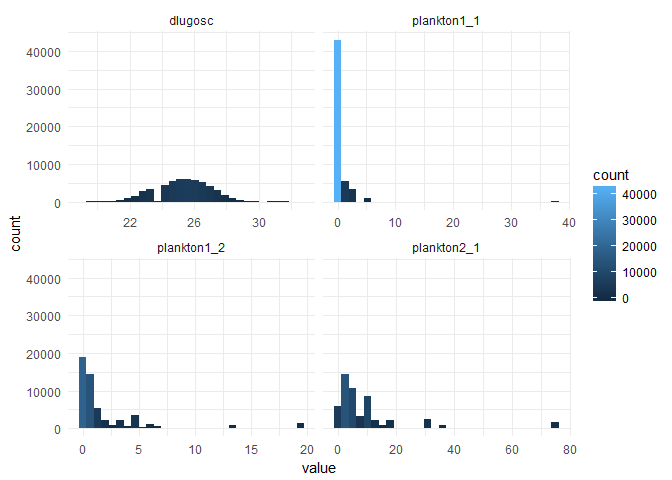

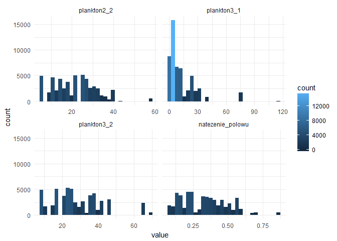

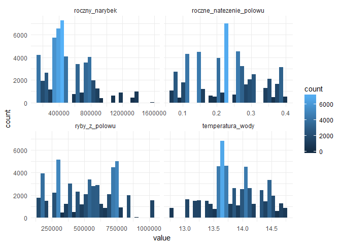

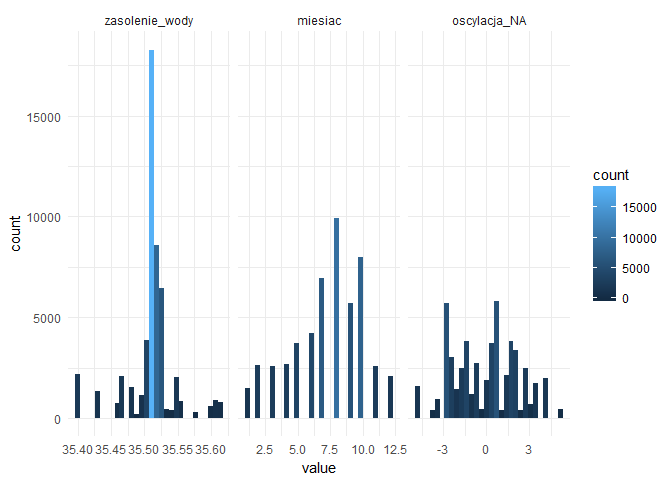

## 3.5 Korelacja pomiędzy atrybutami

- Bardzo duża korelacja pomiędzy następującymi parami atrybutów plankton2_1 i plankton3_1 , plankton2_2 i plankton 3_2, natezenie polowu i roczne natezenie polowu
- Duża ujemna korelacja pomiędzy dwiema parami atrybutów oscylacja_NA i plankton2_1, oscylacja_NA i plankton3_1, a także ryby_z_polowu i roczne_natezenie_polowu
- Warte zaznaczenia jest skorelowanie dlugosci sledzie z temperaturą wody mające wartość -0,46

[interactive chart not shown]

## 3.6 Wykres zależności długości śledzia od czasu

- wyraźnie zauważyć można, że między połowami 10000 a 20000 nastąpił wzrost długości śledzia i najliczniejsze były okazy mające około 27cm.
- od około 30000 ołowu zauważyć można spadek długości śledzia
- pomiędzy połowami 40000-50000 najczęściej występująca długość śledzia oscyluje w okolicach 23 cm

[interactive chart not shown]

# 4 Regresor przewidujący rozmiar śledzia

## 4.1 Implementacja

- Poszukiwane jest wyjaśnienie dlaczego śledź malał w czasie dlatego przy tworzeniu modelu pominięte zostały atrybuty x oraz miesiac
- Pominięto również plankton3_1 oraz plankton3_2 ze względu na bardzo wysoką korelację z odpowiednio plankton2_1 oraz plankton2_2
- podziału na zbiór uczący i testowy dokonano w stosunku 7:3
- podział na zbiory uczący i walidacyjny wykonano przy pomocy pięciokrotnej kroswalidacji
- algorytm wykorzystany do uczenia to random forest, wartość parametru ntree została ustawiona na 10
- do oceny trafności regresji wykorzystano miarey RMSE oraz rsquared
- w poniższej tabeli wyniki 3 modeli uzyskane dla zbioru uczącego, jako finalny wybrany został model przy wartości parametru mtry=2

  | mtry | RMSE | Rsquared |
  | --- | --- | --- |
  | 2 | 1.190286 | 0.4789119 |
  | 6 | 1.198276 | 0.4721902 |
  | 11 | 1.201796 | 0.4692466 |

- Wyniki uzyskane dla zbioru testowego

  | RMSE | 1.185014 |
  | --- | --- |
  | Rsquared | 0.491887 |

- Wykres przedstawiający porównanie wartości rzeczywistych z wartościami uzyskanymi z regresji

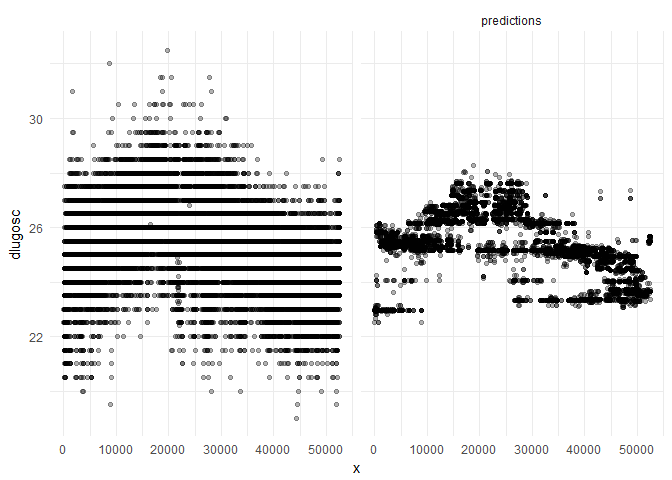

## 4.2 Analiza ważności atrybutów znalezionego modelu regresji, dlaczego śledź zaczął maleć?

- Najważniejszym atrybutem w znalezionym modelu jest temperatura_wody, następnie ryby_z_połowu oraz plankton2_2. Można podejrzewać zatem że bezpośredni wpływ na długość śledzia ma temperatura wody. Jednak takie wyjaśnienie nie jest do końca trafne. Co wydaje się być rzeczywistą przyczyną spadku rozmiaru śledzia jest mniejsza dostępność planktonu (ze znalezionego modelu bezpośrednio wynika, ze wazny jest plankton2_2, poniżej dodatkowe porównanie czy dostępność pozostałych także jest zależna od temperatury i wpływa na rozmiar śledzia ). Mniej pożywienia przekłada się na mniejszy rozmiar ryb. Z kolei spadek dostępności planktonu, który potencjalnie jest bezpośrednio bardziej zależny od temperatury_wody.Ten wniosek, bezpośrednio doprowadził autora do kolejnych przemyśleń, że skoro występowanie planktonu jest zależne od temperatury wody to być może zależy także od zasolenia wody(uplasowało się w znalezionym modelu jako czwarty najważniejszy atrybut).

  ```
  atrybut                       Overall
  ------------------------  -----------
  temperatura_wody           100.000000
  ryby_z_polowu               49.108604
  plankton2_2                 48.000004
  zasolenie_wody              43.609363
  roczny_narybek              32.548262
  natezenie_polowu            28.777016
  plankton1_2                 21.480224
  plankton1_1                 20.380898
  oscylacja_NA                12.990035
  plankton2_1                  8.063256
  roczne_natezenie_polowu      0.000000
  ```

- Wykresy przedstawiające dostępność planktonu w punktach o danej długości i w danym momencie
  - Dostępność plankton1_1 i plankton1_2 nie ma praktycznie żadnego wpływu na długość śledzia.
  - Podczas wzrostu rozmiaru śledzia, (który nastąpił pomiędzy 10000 a 20000 jednostką na osi x) dostępność wszystkich planktonów poza wymienionymi w punkcie wyżej jest duża. Szczególnie wyraźne są skupiska o wysokiej dostępności planktonu2_1 oraz planktonu3_1.

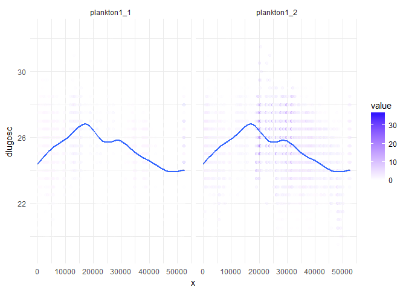

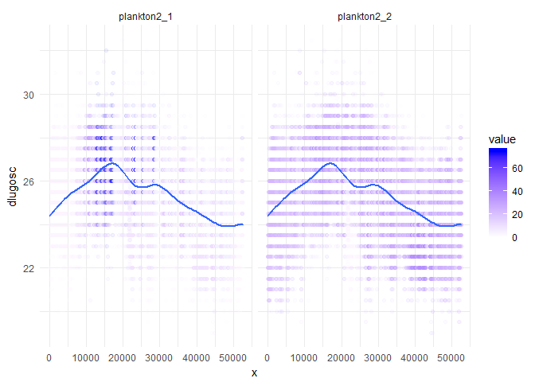

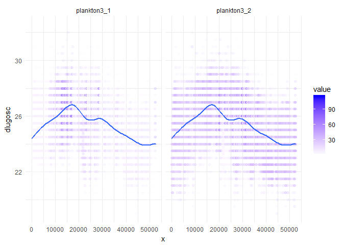

- Poniżej wykresy przedstawiające dostępności planktonu w zależności od temperatury wody i czasu. Można zauważyć, że dostępności wszystkich wyróżnionych typów planktonu mają skupiska najwyższych wartości gdy temperatura ma wartość w pobliżu 13,5 lub mniej. Wraz ze wzrostem temperatury wody(wyraźnie rośnie z czasem) maleje dostępność planktonu.

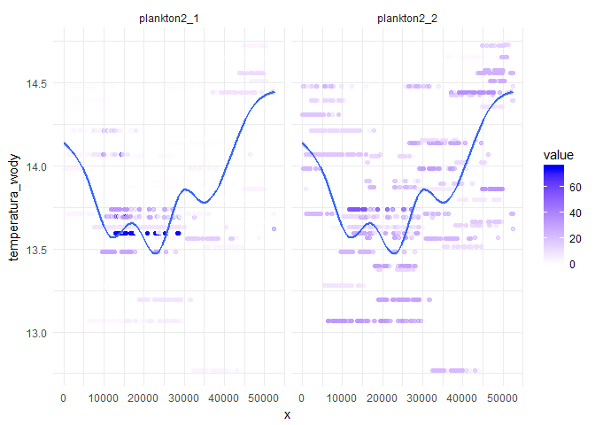

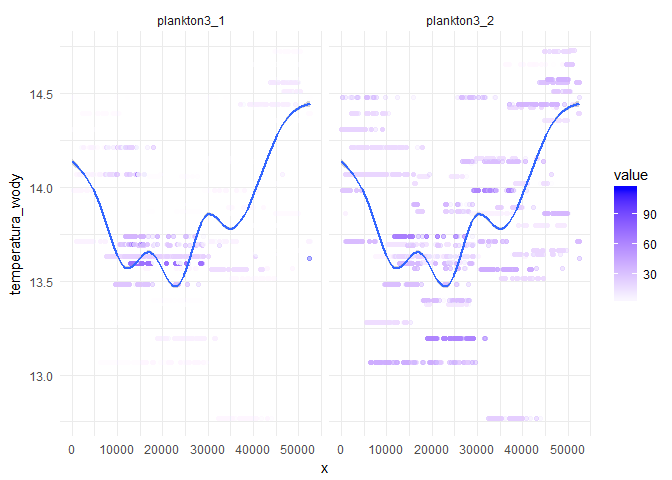

- Poniżej wykresy przedstawiające dostępności planktonu w zależności od zasolenia wody i czasu. Zauważalna jest podobna prawidłowość jak przy wykresach z temperaturą, istnieją wartości zasolenia wody (pomiędzy 35.45 oraz 35.50), w których dostępność planktonu jest zdecydowanie większa niż w pozostałych punktach.

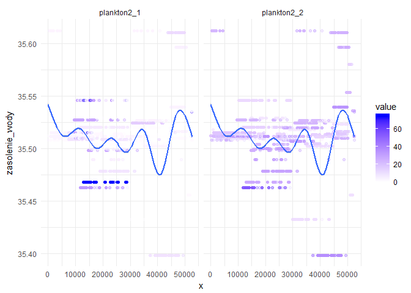

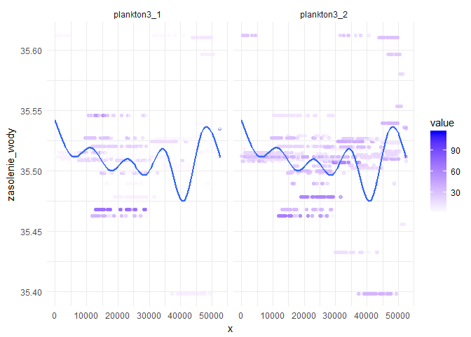

# 5 Wnioski

Na przestrzeni ostatnich 60 lat można zauważyc stopniowy spadek długości śledzia oceanicznego wyławianego w Europie.Bezpośrednio spowodowany jest on spadkiem dostępności planktonu(gatunków Calanus helgolandicus oraz widłonogów). Natomiast coraz mniejsza dostępność planktonu jest następstwem dwóch czynników. Pierwszym z nich jest podwyższenie temperatury wody w oceanach i morzach. Drugim czynnikiem jest poziom zasolenia wody, który musi mieć odpowiednią wartość by pozwolić na rozwój większej ilości planktonu.